# 4_Clustering con dia laborable - fin semana - festivo - precio y demanda

# 4. Cluster con las variables dia de la semana, precio medio y demanda

# Nota: Este resultado corresponde al apartado 2.6.1 K-means precio medio, demanda, dia de la semana

```r
#Creamos dummy variable con los dias festivos de todos los a??os
festivos<-ifelse(electricity_prices$Date=="2014-12-25"|
                  electricity_prices$Date=="2014-01-01"|
                  electricity_prices$Date=="2014-01-06"|
                  electricity_prices$Date=="2014-05-01"|
                  electricity_prices$Date=="2014-08-15"|
                  electricity_prices$Date=="2014-10-12"|
                  electricity_prices$Date=="2014-11-01"|
                  electricity_prices$Date=="2014-12-06"|
                  electricity_prices$Date=="2014-12-08"|
                  electricity_prices$Date=="2014-12-25"|
                  electricity_prices$Date=="2014-12-25"|
                  electricity_prices$Date=="2015-01-01"|
                  electricity_prices$Date=="2015-01-06"|
                  electricity_prices$Date=="2015-05-01"|
                  electricity_prices$Date=="2015-08-15"|
                  electricity_prices$Date=="2015-10-12"|
                  electricity_prices$Date=="2015-11-01"|
                  electricity_prices$Date=="2015-12-06"|
                  electricity_prices$Date=="2015-12-08"|
                  electricity_prices$Date=="2015-12-25"|
                  electricity_prices$Date=="2016-01-01"|
                  electricity_prices$Date=="2016-01-06"|
                  electricity_prices$Date=="2016-05-01"|
                  electricity_prices$Date=="2016-08-15"|
                  electricity_prices$Date=="2016-10-12"|
                  electricity_prices$Date=="2016-11-01"|
                  electricity_prices$Date=="2016-12-06"|
                  electricity_prices$Date=="2016-12-08"|
                  electricity_prices$Date=="2016-12-25"|
                  electricity_prices$Date=="2017-12-25"|
                  electricity_prices$Date=="2017-01-01"|
                  electricity_prices$Date=="2017-01-06"|
                  electricity_prices$Date=="2017-05-01"|
                  electricity_prices$Date=="2017-08-15"|
                  electricity_prices$Date=="2017-10-12",
                  1,0)
```

```r
#Creamos dummy variable con fin de semana (0 si laborable, 1 si fin de semana)
fin_semana<-ifelse( electricity_prices$DayofWeek==6|
                  electricity_prices$DayofWeek==7,
                  1,0)
```

```r
#Creamos variable categorica con festivo, fin de semana y laborable
parte_dia<-ifelse(festivos==1, "festivo", ifelse (fin_semana==1, "fin semana", "laborable"))
```

```r
#Observamos la frecuencia de observaciones en cada categoria
table(parte_dia)
```

```
parte_dia
   festivo fin semana  laborable
       744       9167      22944
```

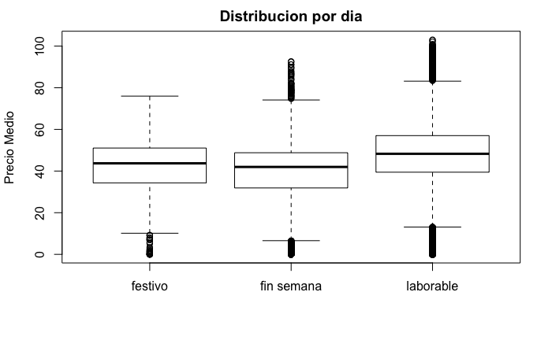

```r
#Observamos la distribucion de los distitnos dias de la semana y el precio
boxplot(PM~parte_dia, main ="Distribucion por dia", ylab="Precio Medio")
```

Se observa una media mas baja de precio en festivos y fines de semana, siendo el precio de los festivos ligeramente mas alto que los fines de semana en general. Los dias laborables son los que presentan precios mas elevados.

```r
#A??adimos columnas al data frame principal con las dummy variables creadas
electricity_prices$laborable<-ifelse(parte_dia=="laborable", 1, 0)
electricity_prices$weekend<-fin_semana
electricity_prices$festivo<-festivos
#Creamos data frame para realizar k-means sobre las variables de interes
clus_day<-electricity_prices[,c("PM", "weekend", "festivo","laborable","dem")]
clus_day1<-clus_day
```

```r
#Observamos la correlacion entre las variables
cor(clus_day)
```

```
                   PM      weekend      festivo  laborable        dem
PM         1.00000000 -0.224996753 -0.031631889  0.2288211  0.4471792
weekend   -0.22499675  1.000000000  0.001595435 -0.9619924 -0.3900985
festivo   -0.03163189  0.001595435  1.000000000 -0.2315983 -0.1552494
laborable  0.22882109 -0.961992395 -0.231598308  1.0000000  0.4201283
dem        0.44717917 -0.390098512 -0.155249424  0.4201283  1.0000000
```

Observamos una correlacion alta entre la demanda y el dia laborable. Por otra parte, aunque la correlacion tiene un valor bajo, los dias laborables influyen positivamente en el precio (el precio suele ser mas alto en estos dias)

```r
#Normalizamos las variables
clus_day1[,c("PM")]<-(clus_day$PM-mean(clus_day$PM))/sd(clus_day$PM)
clus_day1[,c("dem")]<-(clus_day$dem-mean(clus_day$dem))/sd(clus_day$dem)
clus_day1[,c("weekend")]<-(clus_day$weekend-mean(clus_day$weekend))/sd(clus_day$weekend)
clus_day1[,c("festivo")]<-(clus_day$festivo-mean(clus_day$festivo))/sd(clus_day$festivo)
clus_day1[,c("laborable")]<-(clus_day$laborable-mean(clus_day$laborable))/sd(clus_day$laborable)
```

```r
#Observamos la distribucion de las variables normalizadas
summary(clus_day1)
```

```
       PM              weekend           festivo          laborable            dem
 Min.   :-2.89168   Min.   :-0.6323   Min.   :-0.1522   Min.   :-1.5215   Min.   :-2.37606
 1st Qu.:-0.49556   1st Qu.:-0.6323   1st Qu.:-0.1522   1st Qu.:-1.5215   1st Qu.:-0.85510
 Median : 0.06695   Median :-0.6323   Median :-0.1522   Median : 0.6572   Median : 0.05708
 Mean   : 0.00000   Mean   : 0.0000   Mean   : 0.0000   Mean   : 0.0000   Mean   : 0.00000
 3rd Qu.: 0.63138   3rd Qu.: 1.5816   3rd Qu.:-0.1522   3rd Qu.: 0.6572   3rd Qu.: 0.76345
 Max.   : 3.73804   Max.   : 1.5816   Max.   : 6.5695   Max.   : 0.6572   Max.   : 2.87709
```

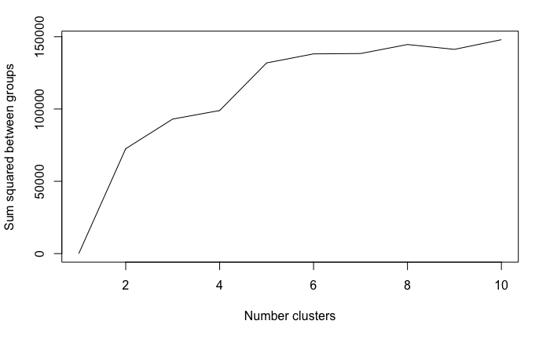

```r
# Creamos grafico con la suma de cuadrados entre grupos para observar el incremento y elegir la opcion mas optima
set.seed(345)
bss_day<-kmeans(clus_day1, centers=1)$betweenss
for(i in 2:10) bss_day[i] <-kmeans(clus_day1, centers=i)$betweenss
plot(1:10, bss_day, type="l", xlab="Number clusters", ylab="Sum squared between groups")
```

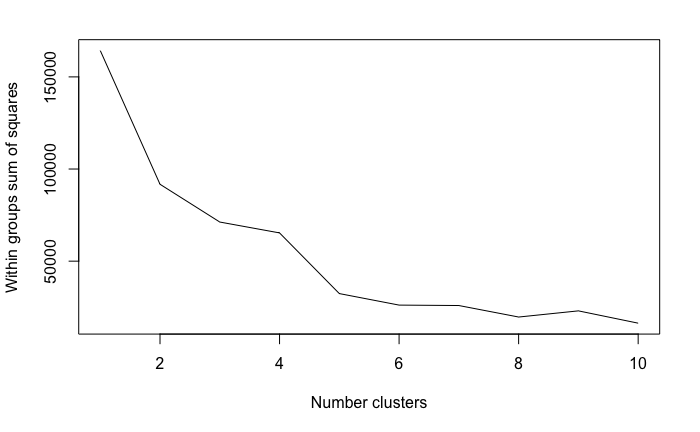

```r
set.seed(345)
bss_day1<-kmeans(clus_day1, centers=1)$tot.withinss
for(i in 2:10) bss_day1[i] <-kmeans(clus_day1, centers=i)$tot.withinss
plot(1:10, bss_day1, type="l", xlab="Number clusters", ylab="Within groups sum of squares")
```

La solucion mas optima es de 5 clusters (a partir de cinco clusters, la SS entre grupos incrementa muy poco)

```r
#Realizamos k-means con 5 centros k=5
set.seed(345)
clus_d_k5<-kmeans(clus_day1, centers=5)
clus_d_k5$centers
```

```
          PM     weekend    festivo  laborable        dem
1 -0.3627003  1.58160337 -0.1522134 -1.5214904 -0.6102498
2 -0.2078064  0.01048125  6.5695230 -1.5214904 -1.0199147
3 -0.3965013 -0.63225053 -0.1522134  0.6572303  0.7547957
4 -0.4339941 -0.63225053 -0.1522134  0.6572303 -0.9379043
5  0.9843534 -0.63010901 -0.1522134  0.6551227  0.8868591
```

```r
#Observamos la media con los valores sin estandarizar
aggregate(clus_day, by=list(clus_d_k5$cluster), mean)
```

| Group.1 | PM | weekend | festivo | laborable | dem |
| --- | --- | --- | --- | --- | --- |
| 1 | 39.29429 | 1.0000000000 | 0 | 0.0000000 | 25594.72 |
| 2 | 41.70097 | 0.2903225806 | 1 | 0.0000000 | 23724.65 |
| 3 | 38.76910 | 0.0000000000 | 0 | 1.0000000 | 31825.98 |
| 4 | 38.18655 | 0.0000000000 | 0 | 1.0000000 | 24099.02 |
| 5 | 60.22430 | 0.0009673259 | 0 | 0.9990327 | 32428.84 |

Interpretacion clusters: Cluster 1: fin de semana, precio medio bajo, demanda baja Cluster 2: festivo, precio intermedio, demanda muy baja Cluster 3: precio medio bajo, dia laborable, demanda alta Cluster 4: precio medio bajo, dia laborable, demanda baja Cluster 5: precio medio alto, laborables y fines de semana con demanda alta

```r
#Observamos el numero de observaciones que caen en cada cluster
table(clus_d_k4$cluster)
```

```
   1    2    3    4    5
9158  744 6438 7211 9304
```

```r
#Representamos la distribucion de los clusters en un scatter plot con precio y demanda donde los colores marcan los clusters
clusters<-clus_d_k5$cluster #Creamos variable con categorias de clusters
clusters$clus_day<-ifelse(clus_d_k5$cluster==1, "cluster 1",
                          ifelse (clus_d_k5$cluster==2, "cluster 2",
                            ifelse (clus_d_k5$cluster==3, "cluster 3",
                              ifelse (clus_d_k5$cluster==4, "cluster 4", "cluster 5"))))
```

```
Coercing LHS to a list
```

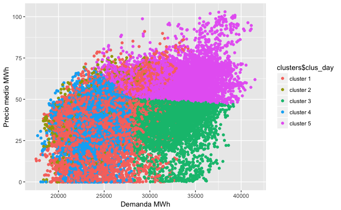

```r
#Representamos mediante ggplot
f_clus_days<-ggplot(aes(x = dem, y = PM), data = electricity_prices) +
  geom_point(aes(col = clusters$clus_day)) +
  xlab("Demanda MWh")+
  ylab("Precio medio MWh")
f_clus_days
```

La diferencia mas significativa es entre los clusters 5 y 3, que son: Cluster 3: precio medio bajo, dia laborable, demanda alta Cluster 5: precio medio alto, dias laborables y fines de semana con demanda alta

```r
#A??adimos columna que marque los clusters en una copia del data frame principal
clus_d<-electricity_prices[,c("Date","Month","DayofWeek","PM", "weekend", "festivo","laborable","dem")]
clus_d$cluster<-clus_d_k4$cluster
```

```r
#Observamos las observaciones que corresponden a fin de semana y forman parte del cluster 5 (precio alto)
obs<-clus_d[ which(clus_d$cluster==5 & clus_d$weekend ==1),]
obs
```

|  | Date | Month | DayofWeek | PM | weekend | festivo | laborable | dem | cluster |
| --- | --- | --- | --- | --- | --- | --- | --- | --- | --- |
| 26794 | 2017-01-21 | 1 | 6 | 87.98 | 1 | 0 | 0 | 33711 | 5 |
| 26795 | 2017-01-21 | 1 | 6 | 86.46 | 1 | 0 | 0 | 34031 | 5 |
| 26802 | 2017-01-21 | 1 | 6 | 89.63 | 1 | 0 | 0 | 33493 | 5 |
| 26803 | 2017-01-21 | 1 | 6 | 91.11 | 1 | 0 | 0 | 35144 | 5 |
| 26804 | 2017-01-21 | 1 | 6 | 87.57 | 1 | 0 | 0 | 35681 | 5 |
| 26805 | 2017-01-21 | 1 | 6 | 89.10 | 1 | 0 | 0 | 35476 | 5 |
| 26827 | 2017-01-22 | 1 | 7 | 92.61 | 1 | 0 | 0 | 33528 | 5 |
| 26828 | 2017-01-22 | 1 | 7 | 92.37 | 1 | 0 | 0 | 34860 | 5 |
| 26829 | 2017-01-22 | 1 | 7 | 87.03 | 1 | 0 | 0 | 35021 | 5 |

Todas la observaciones se producen entre el 21 y el 22 de enero de 2017

```r
#Observamos las observaciones que corresponden a fin de semana sin ser festivo y forman parte del cluster 2
obs1<-clus_d[ which(clus_d$cluster==2 & clus_d$festivo ==0 &clus_d$weekend ==1),]
summary(obs1[,c("Date", "PM", "dem")])
```

```
         Date         PM           dem
 2014-01-01:0   Min.   : NA   Min.   : NA
 2014-01-02:0   1st Qu.: NA   1st Qu.: NA
 2014-01-03:0   Median : NA   Median : NA
 2014-01-04:0   Mean   :NaN   Mean   :NaN
 2014-01-05:0   3rd Qu.: NA   3rd Qu.: NA
 2014-01-06:0   Max.   : NA   Max.   : NA
 (Other)   :0
```

No existen observaciones, por lo tanto, todos los fines de semana incluidos en este cluster son festivos.